# Basic Survival Analysis using Breast Cancer Dataset

## Survival Analysis

Survival analysis is a statistical technique used to analyze data on the time until an event of interest occurs. It can be used to answer a wide range of research questions, such as identifying risk factors for a particular event, predicting the probability of an event occurring at a given time, and comparing the survival experience of different groups of individuals. It is commonly used in medical and healthcare research to study the time until a patient dies or experiences a particular medical event, but it can also be applied to a wide range of other fields, such as customer churn analysis in business or failure analysis in engineering.

The key feature of survival analysis is that it takes into account the possibility of censored data, which occurs when some individuals in the sample do not experience the event of interest before the end of the study period. Censoring can occur for various reasons, such as patients dropping out of a clinical trial, or customers ending their subscription before the end of the study period. Survival analysis allows us to estimate the probability of the event of interest occurring as a function of time, even for individuals who are still being observed at the end of the study period.

There are several statistical methods used in survival analysis, including the Kaplan-Meier estimator, the Cox proportional hazards model, and parametric models such as Weibull and exponential distributions. The Kaplan-Meier estimator is a non-parametric method used to estimate the survival probability, while the Cox proportional hazards model is a semi-parametric method used to model the hazard rate, which is the instantaneous probability of the event of interest occurring at a given time.

## Summary of Dataset

The breast cancer dataset is a publicly available dataset, and is one of the built-in datasets that comes with the scikit-learn library that is commonly used for machine learning and survival analysis tasks. The dataset contains measurements of various features extracted from digitized images of breast mass tissue samples, as well as a binary classification label indicating whether the tissue sample is benign or malignant.

The dataset consists of 569 instances, where each instance corresponds to a tissue sample, and 30 features:

- `mean radius`: the mean of distances from the center to points on the perimeter
- `mean texture`: the standard deviation of gray-scale values
- `mean perimeter`: the perimeter of the tumor
- `mean area`: the area of the tumor
- `mean smoothness`: the local variation in radius lengths
- `mean compactness`: the perimeter^2 / area - 1.0
- `mean concavity`: the severity of concave portions of the contour
- `mean concave points`: the number of concave portions of the contour
- `mean symmetry`: the symmetry of the tumor
- `mean fractal dimension`: "coastline approximation" - 1
- `radius error`: the standard error of the distances from the center to points on the perimeter
- `texture error`: the standard error of gray-scale values
- `perimeter error`: the standard error of the tumor perimeter
- `area error`: the standard error of the tumor area
- `smoothness error`: the standard error of local variation in radius lengths
- `compactness error`: the standard error of perimeter^2 / area - 1.0
- `concavity error`: the standard error of severity of concave portions of the contour
- `concave points error`: the standard error of number of concave portions of the contour
- `symmetry error`: the standard error of tumor symmetry
- `fractal dimension error`: the standard error of "coastline approximation" - 1
- `worst radius`: the largest distance from the center to points on the perimeter
- `worst texture`: the standard deviation of gray-scale values (worst case)
- `worst perimeter`: the perimeter of the tumor (worst case)
- `worst area`: the area of the tumor (worst case)
- `worst smoothness`: the local variation in radius lengths (worst case)
- `worst compactness`: the perimeter^2 / area - 1.0 (worst case)
- `worst concavity`: the severity of concave portions of the contour (worst case)
- `worst concave points`: the number of concave portions of the contour (worst case)
- `worst symmetry`: the symmetry of the tumor (worst case)
- `worst fractal dimension`: "coastline approximation" - 1 (worst case)

```python
# Import relevant libaries
import pandas as pd
import numpy as np
import matplotlib.pyplot as plt
from lifelines import KaplanMeierFitter
from lifelines import CoxPHFitter
from sklearn.datasets import load_breast_cancer
```

## Data Preparation

In this exercise, the breast cancer dataset is loaded using the load_breast_cancer function from scikit-learn, and the data is converted to a Pandas DataFrame. The target variable is then converted to a boolean variable to indicate whether an event has occurred or not.

```python
# Load the breast cancer dataset
data = load_breast_cancer()

df = pd.DataFrame(data.data, columns=data.feature_names)
df['target'] = data.target

# Convert the target variable to a boolean variable
df['event'] = df['target'] == 0
```

```python
# Drop columns that have low variance that may harm convergence
df = df.drop(['mean fractal dimension', 'smoothness error', 'concave points error', 'symmetry error', 'fractal dimension error'], axis=1)
```

## Estimating Survival Probabilities

The [Kaplan-Meier estimator](https://en.wikipedia.org/wiki/Kaplan%E2%80%93Meier_estimator) is used to estimate the survival probabilities as a function of time. Using the `kmf.fit()` method, the Kaplan-Meier estimator is fitted to the `mean radius` variable, and the resulting survival curve is plotted using `kmf.plot()`.

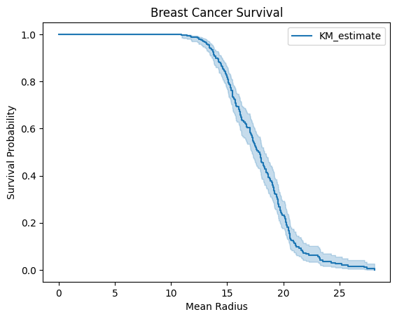

```python
# Fit the Kaplan-Meier estimator to the survival data
kmf = KaplanMeierFitter()
kmf.fit(df['mean radius'], event_observed=df['event'])

# Plot the survival curve
kmf.plot()
plt.title('Breast Cancer Survival')
plt.xlabel('Mean Radius')
plt.ylabel('Survival Probability')
plt.show()
```

## Modeling Hazard Rates

Hazard rate is a concept used in survival analysis to describe the probability of an event (such as death, failure, or churn) occurring at a given time, conditional on the event not having occurred up to that time. It represents the instantaneous risk of experiencing the event, or the rate of occurrence of the event at a specific time, given that the individual or system has survived up to that time.

The Cox proportional hazards model is used to model the hazard rates of the event of interest as a function of the covariates. Using the `cph.fit()` method, the Cox proportional hazards model is fitted to the entire dataset, and the hazard ratios for each covariate are printed using `cph.print_summary()`.

The penalizer parameter applies L1 or L2 (by default) regularization to the coefficients of the model. Regularization can help to reduce overfitting and improve convergence, particularly when the dataset has many covariates. L1 regularization, also known as Lasso regularization, adds a penalty term that is proportional to the absolute values of the model coefficients. This technique can lead to sparse models, where some of the coefficients are set to zero, and therefore can be useful for feature selection. L2 regularization, also known as Ridge regularization, adds a penalty term that is proportional to the square of the model coefficients. This technique can help to avoid overfitting by encouraging the model to use smaller coefficients.

```python
# Fit the Cox proportional hazards model to the survival data
cph = CoxPHFitter(penalizer=0.1)
cph.fit(df, duration_col='mean radius', event_col='event')
cph.print_summary()
```

| model | lifelines.CoxPHFitter |
| --- | --- |
| duration col | 'mean radius' |
| event col | 'event' |
| penalizer | 0.1 |
| l1 ratio | 0.0 |
| baseline estimation | breslow |
| number of observations | 569 |
| number of events observed | 212 |
| partial log-likelihood | -710.63 |
| time fit was run | 2023-04-03 17:13:47 UTC |

|  | coef | exp(coef) | se(coef) | coef lower 95% | coef upper 95% | exp(coef) lower 95% | exp(coef) upper 95% | cmp to | z | p | -log2(p) |
| --- | --- | --- | --- | --- | --- | --- | --- | --- | --- | --- | --- |
| mean texture | -0.01 | 0.99 | 0.02 | -0.05 | 0.04 | 0.95 | 1.04 | 0.00 | -0.29 | 0.77 | 0.37 |
| mean perimeter | -0.03 | 0.97 | 0.01 | -0.04 | -0.02 | 0.96 | 0.98 | 0.00 | -6.43 | <0.005 | 32.82 |
| mean area | -0.00 | 1.00 | 0.00 | -0.00 | -0.00 | 1.00 | 1.00 | 0.00 | -7.05 | <0.005 | 38.99 |
| mean smoothness | 11.44 | 93137.66 | 7.24 | -2.75 | 25.64 | 0.06 | 1.36e+11 | 0.00 | 1.58 | 0.11 | 3.13 |
| mean compactness | -1.50 | 0.22 | 2.07 | -5.55 | 2.55 | 0.00 | 12.84 | 0.00 | -0.72 | 0.47 | 1.09 |
| mean concavity | -3.14 | 0.04 | 1.42 | -5.93 | -0.35 | 0.00 | 0.71 | 0.00 | -2.20 | 0.03 | 5.19 |
| mean concave points | -8.68 | 0.00 | 2.96 | -14.48 | -2.88 | 0.00 | 0.06 | 0.00 | -2.94 | <0.005 | 8.23 |
| mean symmetry | 1.47 | 4.35 | 3.34 | -5.07 | 8.01 | 0.01 | 3012.78 | 0.00 | 0.44 | 0.66 | 0.60 |
| radius error | 0.28 | 1.32 | 0.39 | -0.49 | 1.04 | 0.62 | 2.82 | 0.00 | 0.71 | 0.48 | 1.06 |
| texture error | 0.04 | 1.04 | 0.16 | -0.26 | 0.34 | 0.77 | 1.41 | 0.00 | 0.25 | 0.80 | 0.32 |
| perimeter error | 0.04 | 1.04 | 0.05 | -0.07 | 0.14 | 0.94 | 1.15 | 0.00 | 0.69 | 0.49 | 1.02 |
| area error | -0.00 | 1.00 | 0.00 | -0.01 | 0.00 | 0.99 | 1.00 | 0.00 | -0.89 | 0.37 | 1.42 |
| compactness error | -0.85 | 0.43 | 5.24 | -11.12 | 9.42 | 0.00 | 12352.47 | 0.00 | -0.16 | 0.87 | 0.20 |
| concavity error | -0.57 | 0.57 | 3.61 | -7.64 | 6.51 | 0.00 | 669.62 | 0.00 | -0.16 | 0.88 | 0.19 |
| worst radius | -0.09 | 0.91 | 0.03 | -0.14 | -0.04 | 0.87 | 0.96 | 0.00 | -3.62 | <0.005 | 11.74 |
| worst texture | 0.02 | 1.02 | 0.02 | -0.01 | 0.05 | 0.99 | 1.05 | 0.00 | 1.27 | 0.20 | 2.30 |
| worst perimeter | -0.01 | 0.99 | 0.00 | -0.02 | -0.00 | 0.98 | 1.00 | 0.00 | -3.28 | <0.005 | 9.90 |
| worst area | -0.00 | 1.00 | 0.00 | -0.00 | -0.00 | 1.00 | 1.00 | 0.00 | -3.47 | <0.005 | 10.89 |
| worst smoothness | 13.26 | 5.75e+05 | 3.98 | 5.47 | 21.06 | 236.59 | 1.40e+09 | 0.00 | 3.33 | <0.005 | 10.19 |
| worst compactness | 0.36 | 1.43 | 0.66 | -0.95 | 1.66 | 0.39 | 5.25 | 0.00 | 0.54 | 0.59 | 0.76 |
| worst concavity | 0.10 | 1.10 | 0.51 | -0.90 | 1.09 | 0.41 | 2.99 | 0.00 | 0.20 | 0.85 | 0.24 |
| worst concave points | -0.35 | 0.70 | 1.67 | -3.62 | 2.92 | 0.03 | 18.62 | 0.00 | -0.21 | 0.83 | 0.26 |
| worst symmetry | 2.00 | 7.41 | 1.20 | -0.36 | 4.36 | 0.70 | 78.56 | 0.00 | 1.66 | 0.10 | 3.38 |
| worst fractal dimension | 14.64 | 2.28e+06 | 5.01 | 4.83 | 24.45 | 124.93 | 4.15e+10 | 0.00 | 2.92 | <0.005 | 8.18 |
| target | -1.14 | 0.32 | 0.21 | -1.56 | -0.72 | 0.21 | 0.49 | 0.00 | -5.33 | <0.005 | 23.26 |

| Concordance | 0.96 |
| --- | --- |
| Partial AIC | 1471.26 |
| log-likelihood ratio test | 472.71 on 25 df |
| -log2(p) of ll-ratio test | 277.27 |

The coefficients of the covariates in a Cox proportional hazards model with L2 regularization represent the log hazard ratios, or the relative increase (or decrease) in the hazard rate for a one-unit increase in the corresponding predictor variable, ceteris paribus. The larger the absolute value of the coefficient, the stronger the association between the predictor and the outcome.

With a penalizer strength of 0.1, the coefficients should be interpreted as the log hazard ratios associated with a one-unit increase in the corresponding predictor variable, ceteris paribus, accounting for the regularization effect.